# Evaluating pregnancy outcomes from digital self-records

Laura Symul, Paula Hillard and Susan Holmes

2019

# Abstract

**Background**

Millions of women use mobile phone apps to track their menstrual cycles, fertility and pregnancies by reporting fertility body-signs and ovulation or pregnancy test results.

**Objectives**

Provide a high-resolution description of pregnancy outcomes from self-reported records on a fertility app.

**Methods**

**Conclusion(s)**

The pregnancy loss rates were higher than previously reported for the US population, where most users are based, while pre-term birth rates were lower. These differences could be explained by biases in this self-selected population or inconsistent tracking behaviors. Despite these potential biases, the scale of the dataset allows for a higher resolution view of the distribution of pregnancy duration than previously possible. This study thus demonstrates the utility and limitations of fertility tracking apps, as a promising new tool for studying pregnancy outcomes in large prospective cohorts.

# Figures

## Figure 1

Data collection, Tracking examples, Schematics for the determination of new menstrual cycle starts and pregnancy detection.

[figure not shown]

## Figure 2

Pregnancy Outcomes

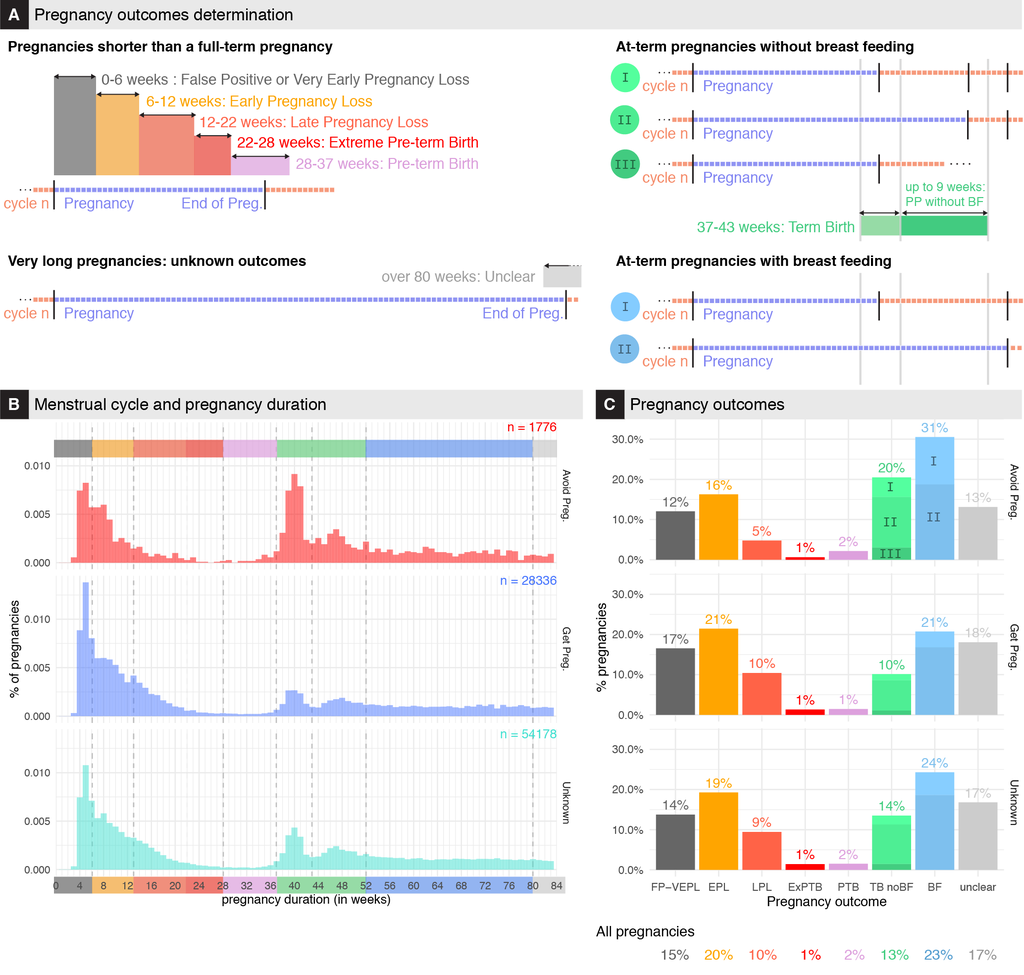

## Figure 3

Live Birth and Pregnancy Losses Rates

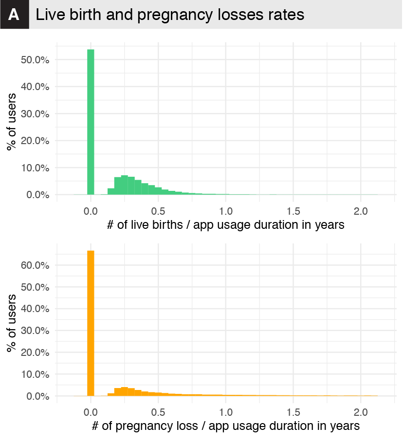

## Figure 4

Predictors of pregnancy losses

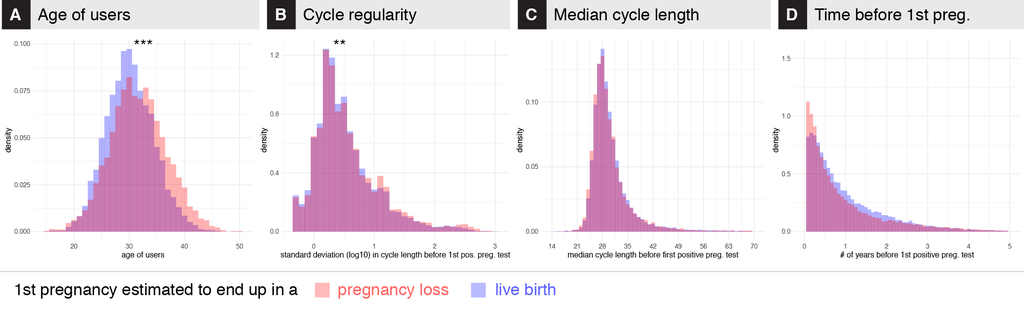

# Pre-print

The current version of the paper can be downloaded on !! medRxiv !!

# Peer-reviewed published article

Coming soon

# Code and Data

Code and aggregated data to reproduce the figures can be found and downloaded on the github repo PL-Public-Repo .

Specifically, click [here](https://lasy.github.io/PL-Public-Repo/Code/Pregnancy_Outcomes_FIGURES.html) for the rendered Rmd (R code // R markdown) used to generate the Figures.

This link will bring you to the rendered R markdown for the full analysis of the data: [Analysis](https://lasy.github.io/PL-Public-Repo/Code/Pregnancy_Outcomes_ANALYSIS.html)

# Contact

Any question or request can be addressed to Laura Symul

lsymul@stanford.edu

laurasymul@gmail.com

[lsy.works](http://lsy.works/)

[twitter](https://twitter.com/LauraSymul) @LauraSymul